# Cálculo Integral

[figure not shown]

## 1. Introducción al Cálculo Integral: El Arte de Medir Áreas

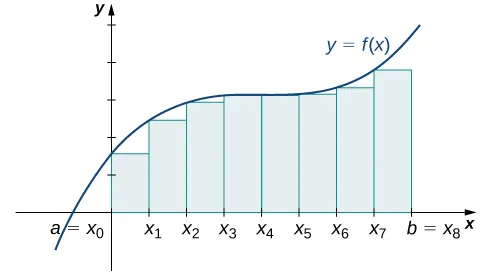

Imagina que quieres conocer el **área de un terreno con forma irregular**. No basta con medir largo y ancho por que el contorno no es recto. Aquí entra el **cálculo integral**. Su idea central es **dividir una región bajo una curva en infinitos pedacitos diminutos**, calcular el área de cada uno y sumarlos todos. Así, incluso las formas más complicadas pueden medirse con precisión.

El cálculo integral no solo sirve para medir áreas: es una herramienta fundamental en física, economía, biología y muchas otras ciencias, donde las cantidades **cambian de manera continua**.

## 2. La integral definida como el límite de una suma de Riemann

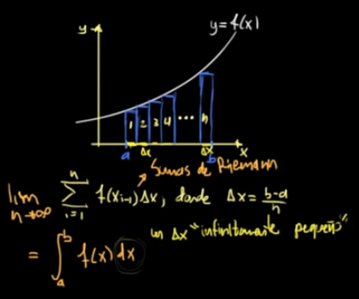

Integral definida. Fuente: Khan Academy

🔁 Repaso:

Para calcular el **área bajo una curva** $f(x)$ entre $x=a$ y $x=b$, podemos aproximarla sumando áreas de **rectángulos** sobre subintervalos:

$$S_n = \sum_{i=1}^n f(x_i^*) \, \Delta x, \quad \Delta x = \frac{b-a}{n}$$

Al aumentar el número de rectángulos ($n \to \infty$), la suma se acerca al valor exacto del área:

$$\int_a^b f(x)\, dx = \lim_{n \to \infty} \sum_{i=1}^n f(x_i^*) \, \Delta
x$$

**Idea clave:** La integral definida es el **límite de estas sumas**, conectando la geometría (área) con el cálculo.

Puedes repasarlo [aquí](https://www.youtube.com/watch?v=lKV1IS2-OAk&t=59s)

📝 Práctica:

Resuelve estas sumas de Riemann. Aunque aun no sabes como calcularla se agrega el valor de la integral para que veas hasta donde te aproximaste.

**1.** Sea $f(x) = x$ en el intervalo $[0, 2]$. Calcula una suma de Riemann siguiendo los siguientes pasos:

- Divide el intervalo en 4 rectángulos ($\Delta x = 0.5$).
- Toma la altura de cada rectángulo en el extremo derecho: $f(0.5)=0.5, f(1)=1$…
- Calcula la suma de áreas como: $S_4 = 0.5 \cdot (0.5 + 1 + ...) = ...$
- Si aumentas los rectángulos, la suma se acerca al valor exacto de la integral: $\int_0^2 x \, dx = 2$

**2.** Sea la función cuadrática $f(x) = x^2$. Calcula el área bajo la curva entre $x=0$ y $x=2$.

- Divide el intervalo $[0,2]$ en 4 partes iguales: $\Delta x = 0.5$.
- El resultado al que deberías llegar es 3,75 mientras que el resultado exacto con integral es $\tfrac{8}{3} \approx 2.67$.

## 3. Teorema fundamental del cálculo

🔁 Repaso:

El **teorema fundamental del cálculo** conecta dos mundos:

- El de la acumulación (integrales definidas).
- El del cambio instantáneo (derivadas).

Si $F(t)$ es una primitiva (antiderivada) de $f(t)$, entonces:

$$\int_a^b f(t)\,dt = F(b) - F(a)$$

Esto nos permite calcular el área o la acumulación **sin necesidad de aproximar con infinitos rectángulos**: basta con encontrar una función cuya derivada sea $f(t)$.

📝 Práctica:

Resuelve estos ejercicios pero no pierdas de vista que estás calculando el área bajo la curva que representa la función.

**1.** Encuentra la solución exacta para la integral de los ejercicios **1** y **2** de la sección anterior.

**2.** Resuelve las siguientes integrales ingeniándotelas para encontrar la primitiva (o antiderivada):

- **a)** $\int_0^4 5 \, dx$
- **b)** $\int_1^3 (2x+1) \, dx$
- **c)** $\int_0^2 x^2 \, dx$
- **d)** $\int_{-1}^2 (x^3 + 2x) \, dx$

## 4. Problemas contextualizados

📝 Práctica:

Resuelve estos problemas en donde la **integral definida** representa una magnitud física. Aquí verás cómo el área bajo la curva se conecta con la realidad:

**1.** **Distancia recorrida en bicicleta (velocidad-tiempo):**

Un ciclista parte del reposo y su velocidad (en m/s) está dada por la función:

$$v(t) = 2t, \quad 0 \leq t \leq 5 \quad \text{(tiempo en segundos).}$$

¿Cuál es la **distancia recorrida** en esos 5 segundos?

*(Pista: la distancia es el área bajo la curva velocidad-tiempo).*

**2.** **Volumen de agua (caudal-tiempo)**

El caudal de agua que entra en un tanque varía según:

$$Q(t) = 10 + 5t \quad \text{(litros/min)}, \quad 0 \leq t \leq 6 \quad
\text{(min)}.$$

¿Cuántos **litros de agua** ingresaron en total durante los 6 minutos?

*(Pista: volumen = área bajo la curva caudal-tiempo).*

## 5. Propiedades de la integral definida

🔁 Repaso:

Sea $f(x)$ y $g(x)$ funciones integrables en $[a,b]$ y $c$ un número real:

1. **Linealidad**

$$\int_a^b [cf(x) + g(x)] \, dx = c \int_a^b f(x)\, dx + \int_a^b g(x)\,
dx$$

2. **Cambio de límites**

$$\int_a^b f(x)\, dx = -\int_b^a f(x)\, dx$$

3. **Intervalo nulo**

$$\int_a^a f(x)\, dx = 0$$

4. **Aditividad de intervalos**

$$\int_a^c f(x)\, dx + \int_c^b f(x)\, dx = \int_a^b f(x)\, dx$$

5. **Positividad** (si $f(x) \geq 0$ en $[a,b]$)

$$\int_a^b f(x)\, dx \geq 0$$

6. **Orden** (si $f(x) \leq g(x)$ en $[a,b]$)

$$\int_a^b f(x)\, dx \leq \int_a^b g(x)\, dx$$

Estas propiedades permiten simplificar cálculos y entender el **significado geométrico** de la integral como área.

📝 Práctica:

Resuelve aplicando propiedades:

**1.** $\int_2^2 (x^2+1)\,dx + \int_0^1 x\,dx$

**2.** Usa la **linealidad** para separar: $\int_0^1 (3x^2 + 4x)\,dx$

**3.** Verificar la siguiente igualdad resolviendo ambos miembros y comprobando la igualdad: $\int_0^4 x\,dx = \int_0^2 x\,dx + \int_2^4 x\,dx$

**4.** Verificar la propiedad de orden para $f(x) = x$ y $g(x) = x+1$ en el intervalo $[0,2]$, demostrando que: $\int_0^2 f(x)\,dx \; < \; \int_0^2 g(x)\,dx$

## 6. Integral indefinida

🔁 Repaso:

La **integral indefinida** de una función es el conjunto de sus **antiderivadas** o **primitivas**:

$$\int f(x)\,dx = F(x) + C \quad \text{con } F'(x)=f(x).$$

**Ejemplo:**

$$\int x^2 \, dx = \tfrac{x^3}{3} + C$$

**Diferencia con la definida:**

- **Definida**: da un **número** (área entre $a$ y $b$).
- **Indefinida**: da una **función** (todas las primitivas).

También puedes repasar esto [aquí.](https://www.youtube.com/watch?v=Is6dH965Q6w&t=224s)

📝 Práctica:

**a)** Encontrar estas integrales indefinidas:

**1.** $\int 3,75x \, dx$ **2.** $\int 3\cos(x)\, dx$ **3.** $\int \frac{6}{x}\, dx$

**b)** Resuelve ahora estos [ejercicios](https://es.khanacademy.org/math/ap-calculus-ab/ab-integration-new/ab-6-7/e/antiderivatives).

## 7. Reglas básicas para encontrar integrales indefinidas

### 7a) Regla de la potencia inversa y propiedades

🔁 Repaso:

$$\int x^n \, dx = \frac{x^{n+1}}{n+1} + C \quad \text{(si \(n \neq
-1\))}.$$

Puedes repasar [aquí](https://www.youtube.com/watch?v=JdsgI7lXoNk&t=349s).

📝 Práctica:

**1.** Haz al menos dos ejercicios de [aquí](https://es.khanacademy.org/math/ap-calculus-ab/ab-integration-new/ab-6-8a/e/intro-to-integration).

**2.** Haz al menos dos ejercicios con potencia negativa de [aquí](https://es.khanacademy.org/math/ap-calculus-ab/ab-integration-new/ab-6-8a/e/basic-integration).

### 7b) Propiedades básicas (linealidad)

🔁 Repaso:

$$\int \big(f(x) + g(x)\big)\,dx = \int f(x)\,dx + \int g(x)\,dx$$

$$\int k \cdot f(x)\,dx = k \cdot \int f(x)\,dx \quad (k \in \mathbb{R})$$

📝 Práctica:

Haz al menos dos ejercicios de [aquí](https://es.khanacademy.org/math/ap-calculus-ab/ab-integration-new/ab-6-8a/e/integration).

### 7c) Simplificar algebraicamente antes de integrar

🔁 Repaso:

Puedes repasarlo aquí.

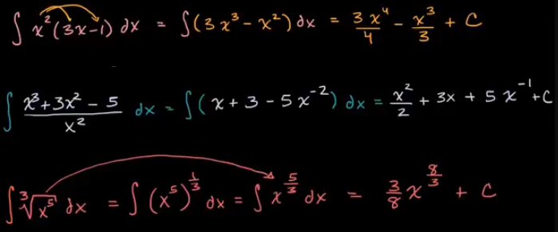

Fuente: Khan Academy

📝 Práctica:

Haz **“todos”** los ejercicios de [aquí](https://es.khanacademy.org/math/ap-calculus-ab/ab-integration-new/ab-6-8a/e/reverse-power-rule-rewriting).

### 7d) Integrales con $e^x$, $1/x$, $cos(x)$ y $sen(x)$

🔁 Repaso:

Puedes repasarlo [aquí](https://www.youtube.com/watch?v=4JwvRi7mQsk&t=456s) y [aquí](https://www.youtube.com/watch?v=nTpYwW5LLq0)

📝 Práctica:

**1.** Haz estos [ejercicios](https://es.khanacademy.org/math/ap-calculus-ab/ab-integration-new/ab-6-8b/e/indefinite-integrals-of-e-x-1-x)

**2.** Haz estos [ejercicios](https://es.khanacademy.org/math/ap-calculus-ab/ab-integration-new/ab-6-8b/e/integrating-sin-cos)

## Método de integración por sustitución o cambio de variables

🔁 Repaso:

Se aplica cuando la integral contiene una función compuesta junto con su derivada o parte de ella. Permite cambiar la variable para simplificar la expresión, resolver en la nueva variable y luego volver a la original. Es básicamente el proceso inverso de la regla de la cadena.

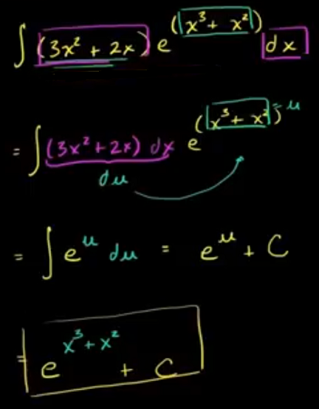

Fuente: Khan Academy

Puedes repasarlo [aquí](https://www.youtube.com/watch?v=DzFToJs5CK8&t=312s).

📝 Práctica:

Resolver estas integrales:

**1.** $\int \frac{1}{x + 6}\,dx$ (Sugerencia: hacer u = x + 6)

**2.** $\int sen(3x-1)\,dx$

**3.** $\int 2x \cdot e^{x^2}\,dx$

**4.** $\int sen(x) \cdot (cos(x))^2\,dx$

**5.** $\int \frac{1}{x \ln x}\,dx$

**6.** $\int \frac{3x^2}{x^3+3}\,dx$

**7.** $\int (x+1) \cdot e^{(3x^2+2x-1)}\,dx$

Algunas respuestas: **1)** ln|x+6| + C; **2)** $-\frac{1}{3} cos(3x-1) + C$; **3)** $e^{x^2} + C$; **4)** $-\frac{1}{3} (cos(x))^3 + C$

## Método de integración por partes

🔁 Repaso:

Este método viene de la regla de la derivada del producto.

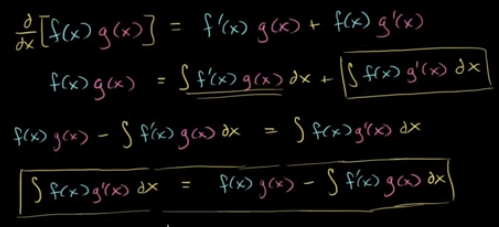

Fuente: Khan Academy

Puedes repasarlo [aquí](https://www.youtube.com/watch?v=SiBcAEVH49g).

**Ejemplo:** Queremos: $\int \ln(x) \,dx$

- Forzamos un producto: $\int \ln(x) \cdot 1\,dx$
- Usamos la fórmula de integración por partes:

$$\int f(x) g'(x) \, dx = f(x) g(x) - \int f'(x) g(x)\, dx.$$

- Elegimos:
  - $f(x) = \ln(x)$ → $f'(x) = \tfrac{1}{x}$
  - $g'(x) = 1$ → $g(x) = x$

Aplicamos la fórmula:

$\int \ln(x)\cdot 1 \, dx = \ln(x)\cdot x - \int \frac{1}{x}\cdot x \, dx$

$= x\ln(x) - \int 1\, dx$

$= x\ln(x) - x + C$

📝 Práctica:

Calcular:

**1.** $\int x \sin(x) \, dx$

**2.** $\int x e^x \, dx$

**3.** $\int x^2 \ln(x) \, dx$

**4.** $\int x \cos(x) \, dx$

**5.** $\int x \sqrt{1 + x} \, dx$

Algunas respuestas: **1)** -x cos(x) + sen(x) + C; **2)** $xe^x - e^x + C$; **3)** $\frac{x^3}{3} ln(x) - \frac{1}{9} x^3 + C$; **4)** $x sen(x) + cos(x) + C$